# Airline on-time performance Dataset

## Preliminary Wrangling

> This document explores a dataset containing flights in the United States, including carriers, arrival and departure delays, and reasons for delays in 2008

```python
# import all packages and set plots to be embedded inline
import numpy as np
import pandas as pd
import matplotlib.pyplot as plt
import seaborn as sb
import datetime
%matplotlib inline
```

> Load in your dataset and describe its properties through the questions below. Try and motivate your exploration goals through this section.

```python
df=pd.read_csv('./data/2008.csv')
```

```python
# Drop duplicate rows
df.drop_duplicates(keep='first',inplace=True)
```

```python
# High level over view of data shape and composition
print(df.info())
df.head(10)
```

```
<class 'pandas.core.frame.DataFrame'>
Int64Index: 7009724 entries, 0 to 7009727
Data columns (total 29 columns):
Year                 int64
Month                int64
DayofMonth           int64
DayOfWeek            int64
DepTime              float64
CRSDepTime           int64
ArrTime              float64
CRSArrTime           int64
UniqueCarrier        object
FlightNum            int64
TailNum              object
ActualElapsedTime    float64
CRSElapsedTime       float64
AirTime              float64
ArrDelay             float64
DepDelay             float64
Origin               object
Dest                 object
Distance             int64
TaxiIn               float64
TaxiOut              float64
Cancelled            int64
CancellationCode     object
Diverted             int64
CarrierDelay         float64
WeatherDelay         float64
NASDelay             float64
SecurityDelay        float64
LateAircraftDelay    float64
dtypes: float64(14), int64(10), object(5)
memory usage: 1.6+ GB
None
```

|  | Year | Month | DayofMonth | DayOfWeek | DepTime | CRSDepTime | ArrTime | CRSArrTime | UniqueCarrier | FlightNum | ... | TaxiIn | TaxiOut | Cancelled | CancellationCode | Diverted | CarrierDelay | WeatherDelay | NASDelay | SecurityDelay | LateAircraftDelay |
| --- | --- | --- | --- | --- | --- | --- | --- | --- | --- | --- | --- | --- | --- | --- | --- | --- | --- | --- | --- | --- | --- |
| 0 | 2008 | 1 | 3 | 4 | 2003.0 | 1955 | 2211.0 | 2225 | WN | 335 | ... | 4.0 | 8.0 | 0 | NaN | 0 | NaN | NaN | NaN | NaN | NaN |
| 1 | 2008 | 1 | 3 | 4 | 754.0 | 735 | 1002.0 | 1000 | WN | 3231 | ... | 5.0 | 10.0 | 0 | NaN | 0 | NaN | NaN | NaN | NaN | NaN |
| 2 | 2008 | 1 | 3 | 4 | 628.0 | 620 | 804.0 | 750 | WN | 448 | ... | 3.0 | 17.0 | 0 | NaN | 0 | NaN | NaN | NaN | NaN | NaN |
| 3 | 2008 | 1 | 3 | 4 | 926.0 | 930 | 1054.0 | 1100 | WN | 1746 | ... | 3.0 | 7.0 | 0 | NaN | 0 | NaN | NaN | NaN | NaN | NaN |
| 4 | 2008 | 1 | 3 | 4 | 1829.0 | 1755 | 1959.0 | 1925 | WN | 3920 | ... | 3.0 | 10.0 | 0 | NaN | 0 | 2.0 | 0.0 | 0.0 | 0.0 | 32.0 |
| 5 | 2008 | 1 | 3 | 4 | 1940.0 | 1915 | 2121.0 | 2110 | WN | 378 | ... | 4.0 | 10.0 | 0 | NaN | 0 | NaN | NaN | NaN | NaN | NaN |
| 6 | 2008 | 1 | 3 | 4 | 1937.0 | 1830 | 2037.0 | 1940 | WN | 509 | ... | 3.0 | 7.0 | 0 | NaN | 0 | 10.0 | 0.0 | 0.0 | 0.0 | 47.0 |
| 7 | 2008 | 1 | 3 | 4 | 1039.0 | 1040 | 1132.0 | 1150 | WN | 535 | ... | 7.0 | 7.0 | 0 | NaN | 0 | NaN | NaN | NaN | NaN | NaN |
| 8 | 2008 | 1 | 3 | 4 | 617.0 | 615 | 652.0 | 650 | WN | 11 | ... | 6.0 | 19.0 | 0 | NaN | 0 | NaN | NaN | NaN | NaN | NaN |
| 9 | 2008 | 1 | 3 | 4 | 1620.0 | 1620 | 1639.0 | 1655 | WN | 810 | ... | 3.0 | 6.0 | 0 | NaN | 0 | NaN | NaN | NaN | NaN | NaN |

10 rows × 29 columns

```python
# Create date time column
df['Date']=pd.to_datetime(dict(year=df.Year, month=df.Month, day=df.DayofMonth))
```

```python
# Cast Cancelled and Diverted to string
df['Cancelled']=df['Cancelled'].astype('str')
df['Diverted']=df['Diverted'].astype('str')
```

```python
# Descriptive statistics for numeric variables
print(df.describe())
```

```
            Year         Month    DayofMonth     DayOfWeek       DepTime  \
count  7009724.0  7.009724e+06  7.009724e+06  7.009724e+06  6.873478e+06
mean      2008.0  6.375132e+00  1.572801e+01  3.924181e+00  1.333830e+03
std          0.0  3.406736e+00  8.797066e+00  1.988260e+00  4.780689e+02
min       2008.0  1.000000e+00  1.000000e+00  1.000000e+00  1.000000e+00
25%       2008.0  3.000000e+00  8.000000e+00  2.000000e+00  9.280000e+02
50%       2008.0  6.000000e+00  1.600000e+01  4.000000e+00  1.325000e+03
75%       2008.0  9.000000e+00  2.300000e+01  6.000000e+00  1.728000e+03
max       2008.0  1.200000e+01  3.100000e+01  7.000000e+00  2.400000e+03

         CRSDepTime       ArrTime    CRSArrTime     FlightNum  \
count  7.009724e+06  6.858075e+06  7.009724e+06  7.009724e+06
mean   1.326086e+03  1.481258e+03  1.494801e+03  2.224201e+03
std    4.642509e+02  5.052251e+02  4.826728e+02  1.961716e+03
min    0.000000e+00  1.000000e+00  0.000000e+00  1.000000e+00
25%    9.250000e+02  1.107000e+03  1.115000e+03  6.220000e+02
50%    1.320000e+03  1.512000e+03  1.517000e+03  1.571000e+03
75%    1.715000e+03  1.909000e+03  1.907000e+03  3.518000e+03
max    2.359000e+03  2.400000e+03  2.400000e+03  9.743000e+03

       ActualElapsedTime  ...      ArrDelay      DepDelay      Distance  \
count       6.855025e+06  ...  6.855025e+06  6.873478e+06  7.009724e+06
mean        1.273224e+02  ...  8.168445e+00  9.972565e+00  7.263868e+02
std         7.018731e+01  ...  3.850194e+01  3.531127e+01  5.621018e+02
min         1.200000e+01  ... -5.190000e+02 -5.340000e+02  1.100000e+01
25%         7.700000e+01  ... -1.000000e+01 -4.000000e+00  3.250000e+02
50%         1.100000e+02  ... -2.000000e+00 -1.000000e+00  5.810000e+02
75%         1.570000e+02  ...  1.200000e+01  8.000000e+00  9.540000e+02
max         1.379000e+03  ...  2.461000e+03  2.467000e+03  4.962000e+03

             TaxiIn       TaxiOut  CarrierDelay  WeatherDelay      NASDelay  \
count  6.858075e+06  6.872666e+06  1.524733e+06  1.524733e+06  1.524733e+06
mean   6.860851e+00  1.645305e+01  1.577205e+01  3.039035e+00  1.716462e+01
std    4.933651e+00  1.133280e+01  4.009913e+01  1.950289e+01  3.189497e+01
min    0.000000e+00  0.000000e+00  0.000000e+00  0.000000e+00  0.000000e+00
25%    4.000000e+00  1.000000e+01  0.000000e+00  0.000000e+00  0.000000e+00
50%    6.000000e+00  1.400000e+01  0.000000e+00  0.000000e+00  6.000000e+00
75%    8.000000e+00  1.900000e+01  1.600000e+01  0.000000e+00  2.100000e+01
max    3.080000e+02  4.290000e+02  2.436000e+03  1.352000e+03  1.357000e+03

       SecurityDelay  LateAircraftDelay
count   1.524733e+06       1.524733e+06
mean    7.497444e-02       2.077101e+01
std     1.837941e+00       3.925965e+01
min     0.000000e+00       0.000000e+00
25%     0.000000e+00       0.000000e+00
50%     0.000000e+00       0.000000e+00
75%     0.000000e+00       2.600000e+01
max     3.920000e+02       1.316000e+03

[8 rows x 22 columns]
```

### What is the structure of your dataset?

> There are 7009724 unique flights in the dataset with 29 features. Most variables are numeric in nature. I create the Date columns for the analysis of delay through time in 1 year. Cancelled and Diverted features are used to distinguish whether the flight cancelled/ diverted so I cast them to string

### What is/are the main feature(s) of interest in your dataset?

> I am most interested in figuring out what features are best impact the delay time, in particular ArrDelay.

### What features in the dataset do you think will help support your investigation into your feature(s) of interest?

> I would like to look at the effect of date, departure time, carrier, airport, distance, diverted status, reason of delay to delay time.

## Univariate Exploration

I start by looking at the distribution of the main variable of interest: ArrDelay and DepDelay

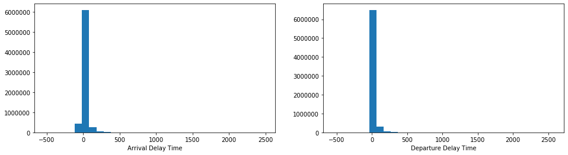

```python
# Start with histogram for numeric variables

binsize=100
plt.figure(figsize=[16,4])
# Arrival Delay
plt.subplot(1,2,1)
bins=np.arange(df['ArrDelay'].min(), df['ArrDelay'].max() +binsize, binsize)
plt.hist(data=df, x='ArrDelay', bins=bins)
plt.xlabel('Arrival Delay Time');

# Departure Delay
plt.subplot(1,2,2)
bins=np.arange(df['DepDelay'].min(), df['DepDelay'].max() +binsize, binsize)
plt.hist(data=df, x='DepDelay', bins=bins)
plt.xlabel('Departure Delay Time');
```

There are not much flights that have delay time more than 250 min and less than -50 min, so I set limit on x axis

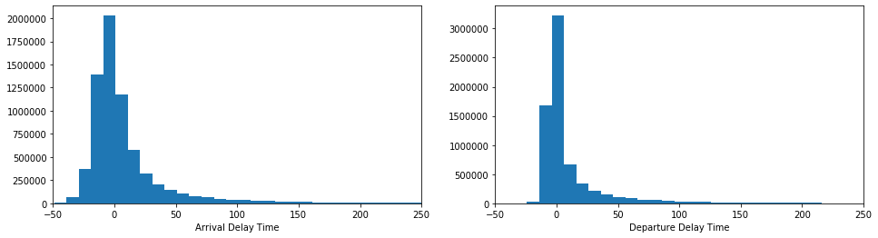

```python
binsize=10
plt.figure(figsize=[16,4])
# Arrival Delay
plt.subplot(1,2,1)
bins=np.arange(df['ArrDelay'].min(), df['ArrDelay'].max() +binsize, binsize)
plt.hist(data=df, x='ArrDelay', bins=bins)
plt.xlabel('Arrival Delay Time')
plt.xlim([-50,250]);

# Departure Delay
plt.subplot(1,2,2)
bins=np.arange(df['DepDelay'].min(), df['DepDelay'].max() +binsize, binsize)
plt.hist(data=df, x='DepDelay', bins=bins)
plt.xlabel('Departure Delay Time')
plt.xlim([-50,250]);
```

[output not shown]

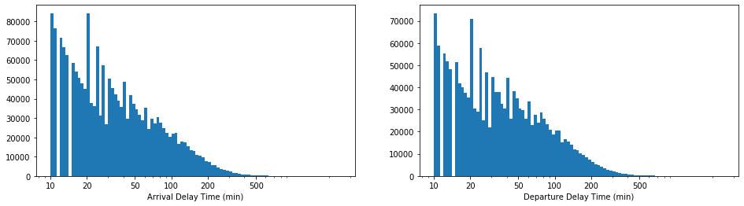

```python
# There are long tails in the distribution so I put it on the log scale instead and only look at the positive number

log_binsize=0.025
plt.figure(figsize=[16,4])
# Arrival Delay
plt.subplot(1,2,1)
bins=10**np.arange(1, np.log10(df['ArrDelay'].max()) +log_binsize, log_binsize)
plt.hist(data=df, x='ArrDelay', bins=bins)
plt.xscale('log')
plt.xticks([10, 20, 50, 100, 200,500],[10, 20, 50, 100, 200,500])
plt.xlabel('Arrival Delay Time (min)')
;

# Departure Delay
plt.subplot(1,2,2)
bins=10**np.arange(1, np.log10(df['DepDelay'].max()) +log_binsize, log_binsize)
plt.hist(data=df, x='DepDelay', bins=bins)
plt.xscale('log')
plt.xticks([10, 20, 50, 100, 200,500],[10, 20, 50, 100, 200,500])
plt.xlabel('Departure Delay Time (min)')
;
```

Distribution of ArrDelay and DepDelay are pretty the same. Delay time has long tail distributions with a lot of flights has delay time less than 20 min and few has long delay time. When plotted on log-scale, data still has right skewed distributions, with 2 peaks on 10 and 20 mins.

Next up, let's look at departure time and arrival time. There 2 variables are not numeric in nature but the histogram plot will help me more easily identify the distribution pattern

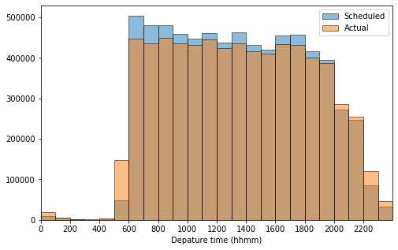

```python
# First is Depature time
binsize=100
plt.figure(figsize=[8,5])
xticks=np.arange(0, 2400, 200)

# Scheduled Departure Time
bins=np.arange(df['CRSDepTime'].min(), df['CRSDepTime'].max() +binsize, binsize)
plt.hist(data=df, x='CRSDepTime', bins=bins, alpha=0.5, label='Scheduled',edgecolor ='k')
plt.hist(data=df, x='DepTime', bins=bins, alpha=0.5, label='Actual',edgecolor ='k')
plt.xlabel('Depature time (hhmm)')
plt.xticks(xticks, xticks)
plt.xlim([0,2400])
plt.legend(loc='upper right');
```

The actual time has distribution move more to 2 ends than the scheduled departure time

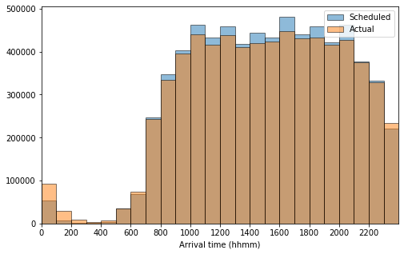

```python
# Arrival time
binsize=100
plt.figure(figsize=[8,5])
xticks=np.arange(0, 2400, 200)

# Scheduled Departure Time
bins=np.arange(df['CRSArrTime'].min(), df['CRSArrTime'].max() +binsize, binsize)
plt.hist(data=df, x='CRSArrTime', bins=bins, alpha=0.5, label='Scheduled',edgecolor ='k')
plt.hist(data=df, x='ArrTime', bins=bins, alpha=0.5, label='Actual',edgecolor ='k')
plt.xlabel('Arrival time (hhmm)')
plt.xticks(xticks, xticks)
plt.xlim([0,2400])
plt.legend(loc='upper right');
```

The arrival time has the distribution pretty the same as departure time, mostly in the range from 6:00 to 22:00, and the actual time is move more to 2 ends than the scheduled time.

Next is the categorical variables: cariers and airports

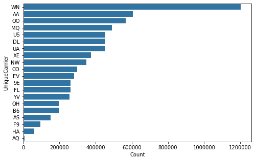

```python
# Unique carriers
plt.figure(figsize=[8,5])
base_color=sb.color_palette()[0]
order=df['UniqueCarrier'].value_counts().index
sb.countplot(data=df, y='UniqueCarrier',color=base_color, order=order)
plt.xlabel('Count');
```

There are 20 different carries, in which WN (Southwest Airlines) has the hight number of flights and AQ has the lowest. Let's look more deeply at the proportion

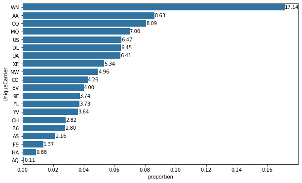

```python
count=df['UniqueCarrier'].value_counts()
order=count.index

#plot
plt.figure(figsize=[10,6])
sb.countplot(data=df, y='UniqueCarrier',color=base_color, order=order)
#Plot proportion instead of count
#Find the max proportion of bar
n_carrier=df['UniqueCarrier'].value_counts().sum()
max_carrier_count=count[0]
max_prop=max_carrier_count/n_carrier
tick_props=np.arange(0,max_prop, 0.02)
tick_names=['{:0.2f}'.format(v) for v in tick_props]
plt.xticks(tick_props*n_carrier, tick_names)
plt.xlabel('proportion');
#print the text on the bar
for i in range (count.shape[0]):
    c=count[i]
    pct_string='{:0.2f}'.format(100*c/n_carrier)
    plt.text(c+1, i, pct_string, va='center');
```

WN takes 17.14% of all the flight while AQ only have 0.11%

Next, I will explore arrival and destination airports distribution

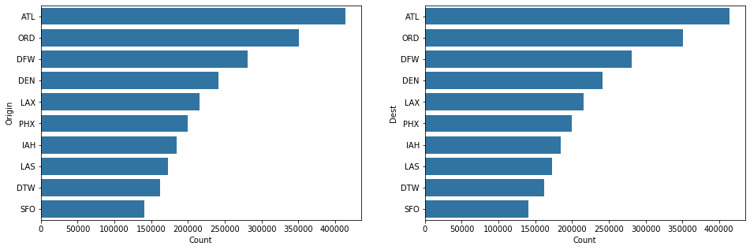

```python
plt.figure(figsize=[16,5])

# Origin airport
plt.subplot(1,2,1)
base_color=sb.color_palette()[0]
top_10=df['Origin'].value_counts()[:10]
order=top_10.index
sb.countplot(data=df, y='Origin',color=base_color, order=order)
plt.xlabel('Count');

# Destination airport
plt.subplot(1,2,2)
top_10=df['Dest'].value_counts()[:10]
order=top_10.index
sb.countplot(data=df, y='Dest',color=base_color, order=order)
plt.xlabel('Count');
```

Because the number of unique airport is big, so I only plot the distribution of top 10. Top 10 airports that have the highest number of flight is the same for origin and destination, so in the bivariate I only look at relationship between origin and other variables.

Next is Diverted status.

```
(-1.1015506040304406,
 1.1005969224006031,
 -1.101032821715144,
 1.1011147047158998)
```

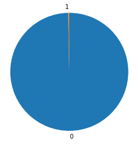

```python
sorted_count=df['Diverted'].value_counts()
plt.pie(sorted_count, labels=sorted_count.index, startangle=90, counterclock=False);
plt.axis('square')
```

Because the number of Diverted Flight is too small, it seem like there is no diverted flights in the chart. In the bivariate exploration, I will look into the relationship with other variables for diverted and non-diverted flights seperately.

Final is reason for delay: CarrierDelay, WeatherDelay, NASDelay, SecurityDelay, LateAircraftDelay

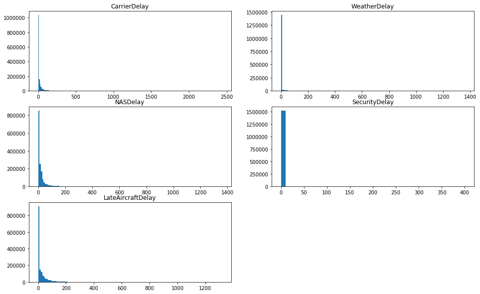

```python
# Create plot matrices for histogram of 5 variables
x_vars=['CarrierDelay', 'WeatherDelay', 'NASDelay', 'SecurityDelay', 'LateAircraftDelay']

fig=plt.figure(figsize=[16,10])
binsize=10
for i, var_name in enumerate(x_vars):
    bins=np.arange(df[var_name].min(), df[var_name].max() +binsize, binsize)
    ax=fig.add_subplot(3,2,i+1)
    plt.hist(data=df, x=var_name, bins=bins)
    ax.set_title(var_name)

plt.show()
```

SecurityDelay and WeatherDelay are mostly less than 10 minutes. CarrierDelay, NASDelay, LateAircraftDelay some time are almost 100 min, but mostly centered in 10 mins. I will look at the distribution on log scale

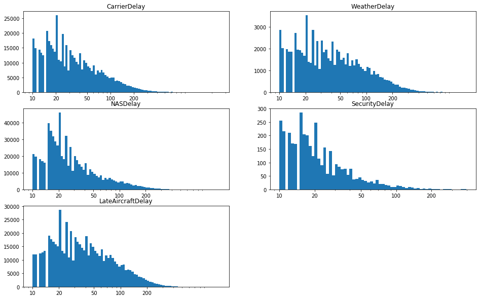

```python
fig=plt.figure(figsize=[16,10])
binsize=0.025
for i, var_name in enumerate(x_vars):
    bins=10**np.arange(1, np.log10(df[var_name].max()) +binsize, binsize)
    ax=fig.add_subplot(3,2,i+1)
    plt.hist(data=df, x=var_name, bins=bins)
    plt.xscale('log')
    plt.xticks([10, 20, 50, 100, 200],[10, 20, 50, 100, 200])
    ax.set_title(var_name)
plt.show()
```

```python
outliers=(df['CarrierDelay']>500)|(df['WeatherDelay']>500)|(df['NASDelay']>500)|(df['SecurityDelay']>100)|(df['LateAircraftDelay']>500)

print(outliers.sum())
print(outliers.sum()/df.shape[0])
print(df.loc[outliers,['ArrDelay','DepDelay','CarrierDelay', 'WeatherDelay', 'NASDelay', 'SecurityDelay', 'LateAircraftDelay']])
```

```
1462
0.000208567412925245
         ArrDelay  DepDelay  CarrierDelay  WeatherDelay  NASDelay  \
101583      502.0     503.0         502.0           0.0       0.0
109138      604.0     605.0         604.0           0.0       0.0
115257      626.0     653.0         626.0           0.0       0.0
127839      687.0     652.0         652.0           0.0      35.0
164554      560.0     580.0         560.0           0.0       0.0
...           ...       ...           ...           ...       ...
6980352     755.0     721.0         721.0           0.0      34.0
6980685     507.0     384.0           0.0           0.0     507.0
6983389     905.0     925.0         905.0           0.0       0.0
6986574     620.0     623.0         620.0           0.0       0.0
6992360     782.0     826.0         782.0           0.0       0.0

         SecurityDelay  LateAircraftDelay
101583             0.0                0.0
109138             0.0                0.0
115257             0.0                0.0
127839             0.0                0.0
164554             0.0                0.0
...                ...                ...
6980352            0.0                0.0
6980685            0.0                0.0
6983389            0.0                0.0
6986574            0.0                0.0
6992360            0.0                0.0

[1462 rows x 7 columns]
```

```python
df.loc[(df['CarrierDelay'].notnull())&(df['ArrDelay']!=(df.CarrierDelay + df.WeatherDelay +df.NASDelay+df.SecurityDelay+df.LateAircraftDelay))]
```

|  | Year | Month | DayofMonth | DayOfWeek | DepTime | CRSDepTime | ArrTime | CRSArrTime | UniqueCarrier | FlightNum | ... | TaxiOut | Cancelled | CancellationCode | Diverted | CarrierDelay | WeatherDelay | NASDelay | SecurityDelay | LateAircraftDelay | Date |
| --- | --- | --- | --- | --- | --- | --- | --- | --- | --- | --- | --- | --- | --- | --- | --- | --- | --- | --- | --- | --- | --- |

0 rows × 30 columns

Above result state that(CarrierDelay + WeatherDelay +NASDelay+SecurityDelay+LateAircraftDelay)=ArrDelay. So I will explore the proportion of each delay reason on the total Arrival Delay Time

```python
# melt to see the proportion of each delay reason on the total arrival delay time
df_cut=df[['FlightNum','TailNum','Month','Date','DepTime','UniqueCarrier','Origin','CRSArrTime','ArrDelay','CarrierDelay', 'WeatherDelay', 'NASDelay', 'SecurityDelay', 'LateAircraftDelay']]
df_reason=df_cut.melt(id_vars=['FlightNum','TailNum','Month','Date','DepTime','UniqueCarrier','Origin','CRSArrTime','ArrDelay'],
              value_vars=['CarrierDelay', 'WeatherDelay', 'NASDelay', 'SecurityDelay', 'LateAircraftDelay'],
              var_name='Reason', value_name='Time')
df_reason=df_reason.loc[df_reason.Time.notnull()]
```

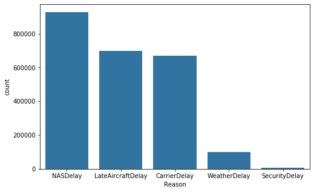

```python
#Plot bar chart for the orcur time of each reason
df_reason_short=df_reason.loc[df_reason.Time!=0.0]
plt.figure(figsize=[8,5])
reason_order=df_reason_short['Reason'].value_counts().index
sb.countplot(data=df_reason_short, x='Reason', order=reason_order, color=base_color);
```

On the orcurring time aspect, NASDelay is the most frequently orcurr and weather delay and security delay have the least frequency. But we should look at the time and percentage on total arrival delay time for a bigger picture.

### Discuss the distribution(s) of your variable(s) of interest. Were there any unusual points? Did you need to perform any transformations?

> The arrival delay time and departure delay time took on a large range of value and shared the same shape of distribution, so I decided to focus on arrival delay time in the next explorations. When using a log transformation, the data look right skewed, with 2 peaks at 10 and 20 mins

### Of the features you investigated, were there any unusual distributions? Did you perform any operations on the data to tidy, adjust, or change the form of the data? If so, why did you do this?

> For Origin and Dest variable, because there are too many unique value, I only look at top 10 cariers that have the highest number of flight, and found that top 10 airports are the same for origin and destination.

> For last 5 variables that hold time in each delay category, I also have to use the log scale to have a better view on the data distribution. Those plot are pretty the same, all are right skewed and have long tail on right limit. So I see the high outliers and they are valid points. Last point is that sum of these 5 variables is equal to the ArrDelay value, there is no exception. So I have melted the 5 reason variables to one column named 'Reason' and figured out the frequency of each reason, they have decreasing frequency in following order: NASDelay, LateAircraftDelay, CarrierDelay, WeatherDelay and SecurityDelay

## Bivariate Exploration

To start off with, I want to look at the pairwise correlation present between features in the data

```python
num_vars=['ArrDelay','Distance','CarrierDelay', 'WeatherDelay', 'NASDelay', 'SecurityDelay', 'LateAircraftDelay']
cat_vars=['Month','DayofMonth','DayOfWeek','UniqueCarrier','Origin','Diverted']
```

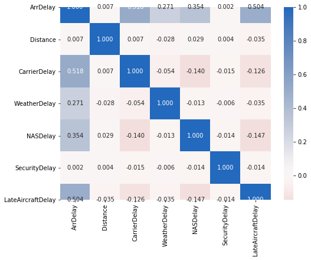

```python
# Correlation plot
plt.figure(figsize=[8,6])
sb.heatmap(df[num_vars].corr(), annot=True, fmt='.3f', cmap='vlag_r', center=0)
plt.show()
```

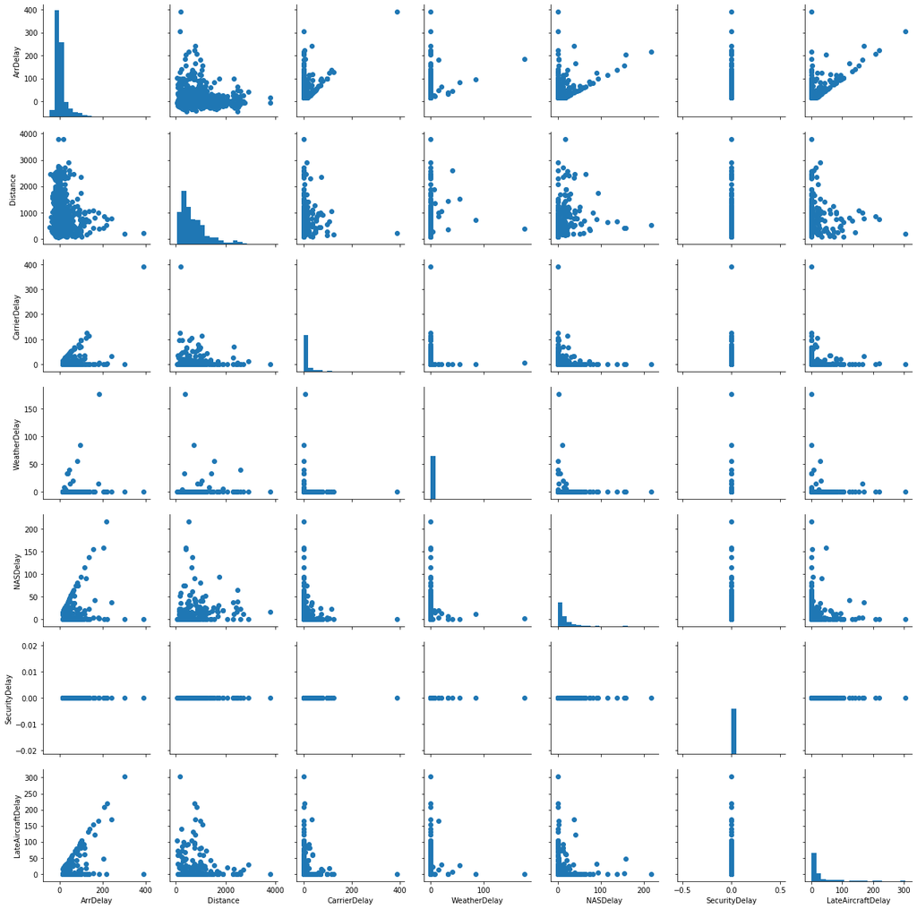

```python
# Plot matrix: Sample 1000 flights so that plots are clearer and thet render faster
sample=np.random.choice(df.shape[0], 1000, replace=False)
df_sample=df.loc[sample,:]

g=sb.PairGrid(data=df_sample, vars=num_vars)
g=g.map_diag(plt.hist, bins=20)
g.map_offdiag(plt.scatter);
```

As expected above, only CarrierDelay and LateAircraftDelay have correlation with ArrDelay. Although other reasons are components of ArrDelay, there are many records that don't have value in any reason, and especially WeatherDelay and SecurityDelay, most of the point is 0.

For plot of numeric features against categorical features, some of categorical variables have too many unique values, it will make the matrix hard to demonstrate clearly the relationship. So I will plot each categorical features seperately.

First is ArrDelay by time variables

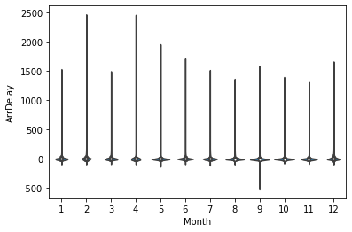

```python
# By month
sb.violinplot(data=df, x='Month', y='ArrDelay', color=base_color);
```

```python
pd.set_option("display.max_columns", None)
df.loc[df['ArrDelay']<-200]
```

|  | Year | Month | DayofMonth | DayOfWeek | DepTime | CRSDepTime | ArrTime | CRSArrTime | UniqueCarrier | FlightNum | TailNum | ActualElapsedTime | CRSElapsedTime | AirTime | ArrDelay | DepDelay | Origin | Dest | Distance | TaxiIn | TaxiOut | Cancelled | CancellationCode | Diverted | CarrierDelay | WeatherDelay | NASDelay | SecurityDelay | LateAircraftDelay | … |
| --- | --- | --- | --- | --- | --- | --- | --- | --- | --- | --- | --- | --- | --- | --- | --- | --- | --- | --- | --- | --- | --- | --- | --- | --- | --- | --- | --- | --- | --- | --- |
| 5179806 | 2008 | 9 | 29 | 1 | 136.0 | 1030 | 456.0 | 1335 | HA | 7 | N587HA | 380.0 | 365.0 | 355.0 | -519.0 | -534.0 | LAS | HNL | 2762 | 5.0 | 20.0 | 0 | NaN | 0 | NaN | NaN | NaN | NaN | NaN | … |

From the violin plot, we can see that the longest delay fall in February and April.There is one outlier in September with the ArrDelay is -519 mins, DepDelay is -534 mins. Most of the value is in the range from -10 to 10 mins

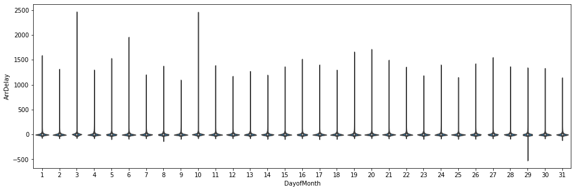

```python
# By Day of Month
plt.figure(figsize=[16,5])
sb.violinplot(data=df, x='DayofMonth', y='ArrDelay', color=base_color);
```

The day in month that has longest delay time is 3rd, 6th and 10th, we still have an outlier in 29th as above. Other days have quite the same distribution.

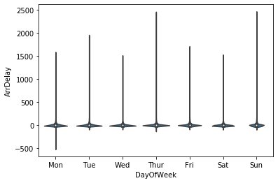

```python
# By Day of Week
sb.violinplot(data=df, x='DayOfWeek', y='ArrDelay', color=base_color)
plt.xticks(np.arange(0,7,1), ['Mon','Tue','Wed','Thur','Fri','Sat','Sun']);
```

Two days in the week that have the longest delay time is Thur and Sun

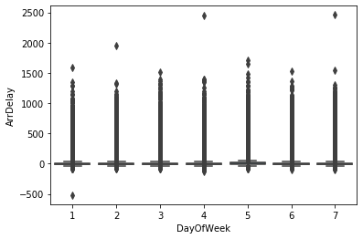

```python
sb.boxplot(data=df, x='DayOfWeek', y='ArrDelay', color=base_color);
```

When looking at the boxplot, we can see that the delay time has almost the same distribution across week day, with some extraordinary outliers on Thur and Sun. Fri has a little wider IQR, which mean the flights in that day have more chance to not follow the scheduled time.

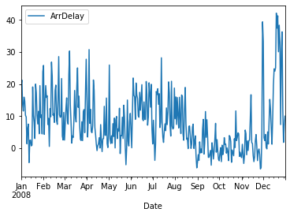

```python
# By date
fig=plt.figure(figsize=[16,10])
delay_by_date=df.groupby('Date')['ArrDelay'].mean().reset_index()
delay_by_date.plot('Date','ArrDelay')
plt.show();
```

In the first half of the year, the delay time is quite stable, it decrease in the last 3 months and suddenly increase in the end of the year.

Next we will look at relationship between arrival time and arrival delay time

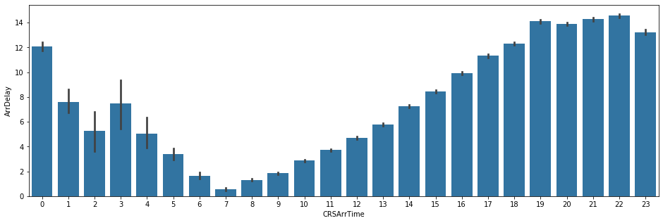

```python
plt.figure(figsize=[16,5])

bin_center=np.arange(df['CRSDepTime'].min(), df['CRSDepTime'].max() +100, 100)
arrtime_binned=pd.cut(df['CRSArrTime'], bin_center, include_lowest=True)
sb.barplot( x=arrtime_binned, y=df['ArrDelay'], color=base_color)
plt.xticks(np.arange(0, 24, 1),np.arange(0, 24, 1)) ;
```

Next is UniqueCarrier vs ArrDelay

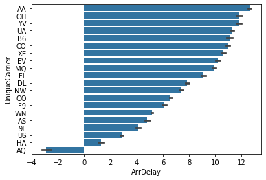

```python
order=df.groupby('UniqueCarrier')['ArrDelay'].mean().sort_values(ascending=False).index
sb.barplot(data=df, x='ArrDelay', y='UniqueCarrier', color=base_color, order=order);
```

Next is Origin airport vs ArrDelay

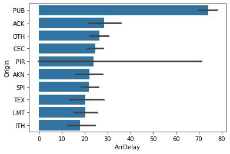

```python
top_10=df.groupby('Origin')['ArrDelay'].mean().sort_values(ascending=False)[:10]
order=top_10.index
sb.barplot(data=df, x='ArrDelay', y='Origin', color=base_color, order=order);
```

Top 10 airports that has the highest number of flight are ATL, ORD, DFW, DEN, LAX, PHX, IAH, LAS, DTW, SFO, which are different from top 10 airports that has the longest delay time

Next is Diverted Status

```python
df.loc[df['Diverted']=='1', 'ArrDelay'].unique()
```

```
array([nan])
```

All the flights that were diverted don't have value in ArrDelay, so the historam we have in the univariate exploration is for non-diverted flights

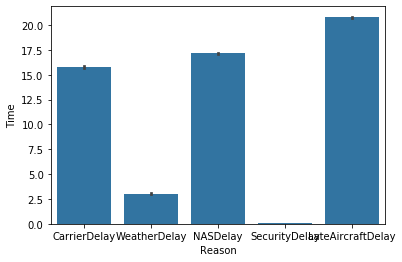

```python
# Plot bar chart for the time delay by each reason
sb.barplot(data=df_reason, x='Reason', y='Time', color=base_color)
```

The order has changed a little bit compared to the count plot. But CarrierDelay, NASDelay and LateAircraftDelay still are the reasons with longest time

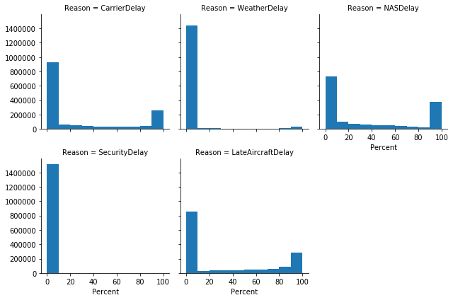

```python
# Plot histogram for the percentage of time delay of each reason on the total arrival delay time
df_reason['Percent']=df_reason['Time']*100/df_reason['ArrDelay']
g=sb.FacetGrid(data=df_reason, col='Reason', col_wrap=3)
g.map(plt.hist, 'Percent', bins=10)
```

When looking at the percentage of each reason on the total arrival delay time, we still can see the same pattern as before, CarrierDelay, NASDelay and LateAircraftDelay are the 3 reasons that happened most often and also account for high proportion in the total delay time.

### Talk about some of the relationships you observed in this part of the investigation. How did the feature(s) of interest vary with other features in the dataset?

> Although the total time of five delay reason is equal to arrival delay time, there are not such a strong relationship between reason with the arrval delay time as expected. This may be as of there are many records only have arrival delay time, not have the time in each reason.

> In the 3rd and 10th of Month, and in Feb and April of year, the delay time is fluctated more than other time. And through the line plot, we can see that the delay time is more stabe in the first haft of the year then decrease in the Sep, Oct, Nov and suddenly sharply increase in the end of the year.

> For carriers and airports, the partern is not the same as in the last section. The carriers and airports that have the highest number of flights are not the one has longest delay time

### Did you observe any interesting relationships between the other features (not the main feature(s) of interest)?

> Looking at the correlation matrix, I don't see any relationship between other features, especially Distance, which seem to not have any correlation with other delay time

## Multivariate Exploration

> The main thing I want to explore in this part of the analysis is how the five reason of delay distribute across other qualitative variables

[figure not shown]

```python
# The cariers
carriers_order=df_reason.groupby('UniqueCarrier')['ArrDelay'].mean().sort_values(ascending=False).index
reason_order=['LateAircraftDelay','NASDelay','CarrierDelay','WeatherDelay','SecurityDelay']
artists=[]
baselines=np.zeros(len(carriers_order))
carrier_time=df_reason.groupby('UniqueCarrier')['Time'].mean()
for i in range(5):
    reason=reason_order[i]
    inner_time=df_reason[df_reason['Reason']==reason].groupby('UniqueCarrier')['Time'].mean()
    inner_prop=inner_time/carrier_time
    bars=plt.bar(x=np.arange(len(carriers_order)),height=inner_prop[carriers_order],
                 bottom=baselines)
    artists.append(bars)
    baselines+=inner_prop[carriers_order];
plt.xticks(np.arange(len(carriers_order)), carriers_order)
plt.yticks(np.arange(0,5,1), np.arange(0,1,0.2))
plt.legend(reversed(artists), reversed(reason_order), framealpha = 1,
           bbox_to_anchor = (1, 0.5), loc = 6);
```

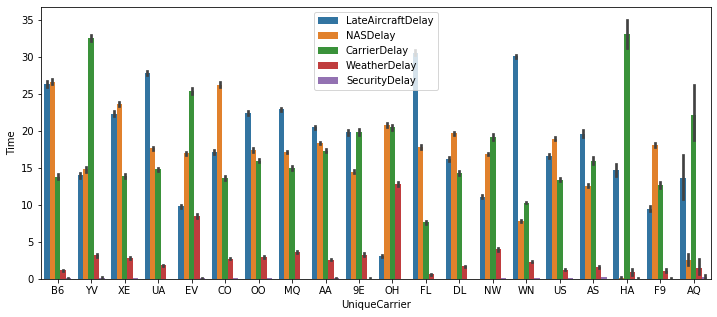

```python
#cluster bar chart
plt.figure(figsize = [12, 5])

sb.barplot(data = df_reason, x = 'UniqueCarrier',y='Time', hue = 'Reason',
             order = carriers_order, hue_order = reason_order)
plt.legend();
```

Next is to see the change of time delay in 5 reason by date

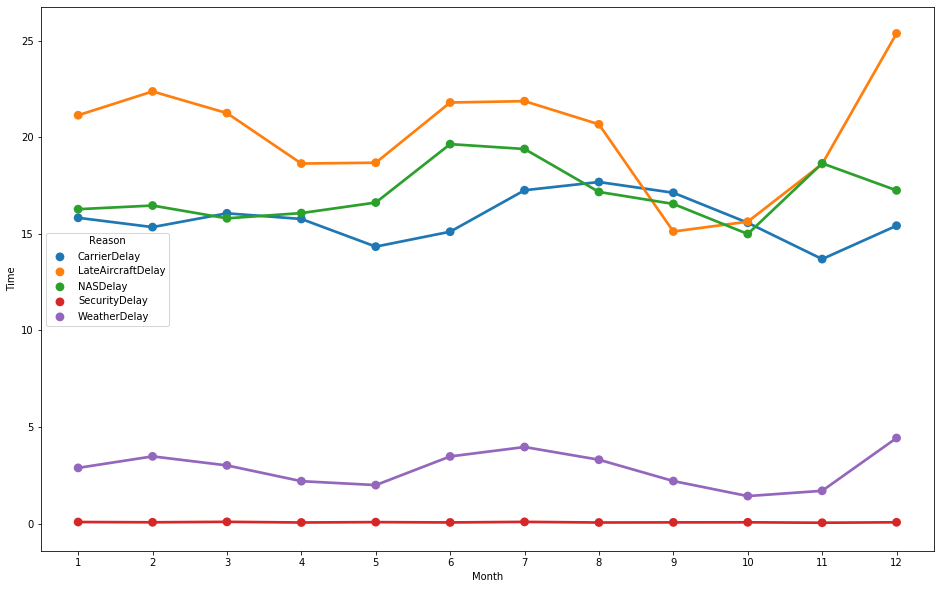

```python
fig=plt.figure(figsize=[16,10])
delay_by_date=df_reason.groupby(['Month','Reason'])['Time'].mean().reset_index()
sb.pointplot('Month', 'Time', data=delay_by_date, hue='Reason')
plt.show();
```

SecurityDelay and WeatherDelay is quite stable by time, while LateAircraftDelay and NASDelay increase in the middle of the year then fail in Sep and increase again in the end of year, CarrierDelay not follow the same pattern

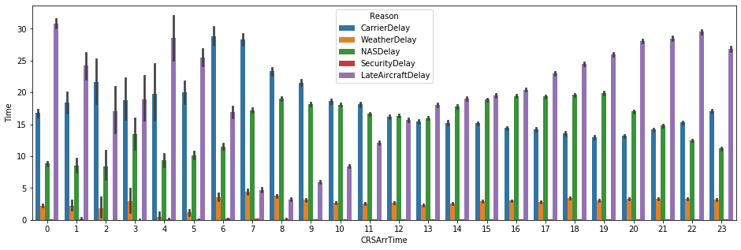

```python
# Scheduled Arrival Time
plt.figure(figsize=[16,5])

bin_center=np.arange(df_reason['CRSArrTime'].min(), df_reason['CRSArrTime'].max() +100, 100)
arrtime_binned=pd.cut(df_reason['CRSArrTime'], bin_center, include_lowest=True)
sb.barplot( data=df_reason, x=arrtime_binned, y=df_reason['Time'],hue='Reason')
plt.xticks(np.arange(0, 24, 1),np.arange(0, 24, 1)) ;
```

### Talk about some of the relationships you observed in this part of the investigation. Were there features that strengthened each other in terms of looking at your feature(s) of interest?

> I extended my investigation of the delay time seperated by reason against carriers, time and scheduled arrival time. Because there is not any strong correlation between numeric variable with Delay time, the only thing I can look at here is the trend of delay time (seperated by reason) in other categorical variables.

> For carriers, it spots that LateAircraftDelay, NASDelay and CarrierDelay are still the popular reason in most of carriers, but there is exception for OH, whose WeatherDelay is in top 3.

> About the pattern by time, SecurityDelay and WeatherDelay is quite stable by time, LateAircraftDelay and NASDelay increase in the middle of the year then fail in Sep and increase again in the end of year, CarrierDelay not follow the same pattern.

### Were there any interesting or surprising interactions between features?

> Because there is no correlation between numeric feature, it's quite hard to say whether other qualitative variables have any surprising interaction without any first expectation.

> At the end of your report, make sure that you export the notebook as an html file from the `File > Download as... > HTML` menu. Make sure you keep track of where the exported file goes, so you can put it in the same folder as this notebook for project submission. Also, make sure you remove all of the quote-formatted guide notes like this one before you finish your report!